# Group 22 Project

2022-12-07

Retaining Customers for Regork  
Class: Data Mining (4080-001)  
Author: Roan Zappanti

# Lab Sections

## Prerequities

```r
knitr::opts_chunk$set(
  fig.width = 6, fig.height = 6,
  warning = FALSE, error = FALSE, message = FALSE,
  include = TRUE, echo = TRUE, strip.white = TRUE, highlight = TRUE,
  results = 'hold'
)
```

```r
library(tidyverse)
library(tidymodels)
library(RColorBrewer)
library(vip)
library(kernlab)
library(baguette)
library(pdp)
library(gridExtra)

path <- here::here("Data","customer_retention.csv")
data_tibble <- read_csv(path)
data <- as.data.frame(data_tibble)
```

## Introduction

**The Problem**: Retention, retention, retention! It’s all everyone talks about these days, and for good reason. Regork, working in telecommunications, has noticed an uptick in customer churn. In order to increase retention (and therefore revenue), this analysis looks at the types of customers likely to stay with the company, important features to those customers, and losses based on predicted customers to churn. While this serves as a start to Regork’s machine learning models for retention, it sets a great precedent for continual and marginal improvement and company retention, revenue, and profit.

**Addressing Retention**: In order to properly understand retention, this analysis:

- Identifies trends/relationships among customer information and their churn
- Employs basic logistic regression, regularized + tuned logistic regression, and decision tree modeling to predict future customers that will churn.
- Chooses the best-performing model and tests against provided data
- Develop an action plan based on important features determined, customers identified, and potential lost revenue.

## Exploratory Data Analysis

#### Cleaning the Data

```r
glimpse(data)
```

```
Rows: 6,999
Columns: 20
$ Gender           <chr> "Female", "Male", "Male", "Male", "Female", "Female", "Male",…
$ SeniorCitizen    <dbl> 0, 0, 0, 0, 0, 0, 0, 0, 0, 0, 0, 0, 0, 0, 0, 0, 0, 0, 0, 0, 1…
$ Partner          <chr> "Yes", "No", "No", "No", "No", "No", "No", "No", "Yes", "No",…
$ Dependents       <chr> "No", "No", "No", "No", "No", "No", "Yes", "No", "No", "Yes",…
$ Tenure           <dbl> 1, 34, 2, 45, 2, 8, 22, 10, 28, 62, 13, 16, 58, 49, 25, 69, 5…
$ PhoneService     <chr> "No", "Yes", "Yes", "No", "Yes", "Yes", "Yes", "No", "Yes", "…
$ MultipleLines    <chr> "No phone service", "No", "No", "No phone service", "No", "Ye…
$ InternetService  <chr> "DSL", "DSL", "DSL", "DSL", "Fiber optic", "Fiber optic", "Fi…
$ OnlineSecurity   <chr> "No", "Yes", "Yes", "Yes", "No", "No", "No", "Yes", "No", "Ye…
$ OnlineBackup     <chr> "Yes", "No", "Yes", "No", "No", "No", "Yes", "No", "No", "Yes…
$ DeviceProtection <chr> "No", "Yes", "No", "Yes", "No", "Yes", "No", "No", "Yes", "No…
$ TechSupport      <chr> "No", "No", "No", "Yes", "No", "No", "No", "No", "Yes", "No",…
$ StreamingTV      <chr> "No", "No", "No", "No", "No", "Yes", "Yes", "No", "Yes", "No"…
$ StreamingMovies  <chr> "No", "No", "No", "No", "No", "Yes", "No", "No", "Yes", "No",…
$ Contract         <chr> "Month-to-month", "One year", "Month-to-month", "One year", "…
$ PaperlessBilling <chr> "Yes", "No", "Yes", "No", "Yes", "Yes", "Yes", "No", "Yes", "…
$ PaymentMethod    <chr> "Electronic check", "Mailed check", "Mailed check", "Bank tra…
$ MonthlyCharges   <dbl> 29.85, 56.95, 53.85, 42.30, 70.70, 99.65, 89.10, 29.75, 104.8…
$ TotalCharges     <dbl> 29.85, 1889.50, 108.15, 1840.75, 151.65, 820.50, 1949.40, 301…
$ Status           <chr> "Current", "Current", "Left", "Current", "Left", "Left", "Cur…
```

```r
#Any empty rows or columns? Nope
data <- data[rowSums(is.na(data)) != ncol(data), ]
data <- data[ , colSums(is.na(data)) != nrow(data)]

#It looks like Total Charges is the only column with NA values.
data[!complete.cases(data),]
```

|  | Gender | SeniorCitizen | Partner | Dependents | Tenure | PhoneService | MultipleLines | InternetService | OnlineSecurity | OnlineBackup | DeviceProtection | TechSupport | StreamingTV | StreamingMovies | Contract | PaperlessBilling | PaymentMethod | MonthlyCharges | TotalCharges | Status |
| --- | --- | --- | --- | --- | --- | --- | --- | --- | --- | --- | --- | --- | --- | --- | --- | --- | --- | --- | --- | --- |
| 489 | Female | 0 | Yes | Yes | 0 | No | No phone service | DSL | Yes | No | Yes | Yes | Yes | No | Two year | Yes | Bank transfer (automatic) | 52.55 | NA | Current |
| 754 | Male | 0 | No | Yes | 0 | Yes | No | No | No internet service | No internet service | No internet service | No internet service | No internet service | No internet service | Two year | No | Mailed check | 20.25 | NA | Current |
| 937 | Female | 0 | Yes | Yes | 0 | Yes | No | DSL | Yes | Yes | Yes | No | Yes | Yes | Two year | No | Mailed check | 80.85 | NA | Current |
| 1083 | Male | 0 | Yes | Yes | 0 | Yes | Yes | No | No internet service | No internet service | No internet service | No internet service | No internet service | No internet service | Two year | No | Mailed check | 25.75 | NA | Current |
| 1341 | Female | 0 | Yes | Yes | 0 | No | No phone service | DSL | Yes | Yes | Yes | Yes | Yes | No | Two year | No | Credit card (automatic) | 56.05 | NA | Current |
| 3332 | Male | 0 | Yes | Yes | 0 | Yes | No | No | No internet service | No internet service | No internet service | No internet service | No internet service | No internet service | Two year | No | Mailed check | 19.85 | NA | Current |
| 3827 | Male | 0 | Yes | Yes | 0 | Yes | Yes | No | No internet service | No internet service | No internet service | No internet service | No internet service | No internet service | Two year | No | Mailed check | 25.35 | NA | Current |
| 4381 | Female | 0 | Yes | Yes | 0 | Yes | No | No | No internet service | No internet service | No internet service | No internet service | No internet service | No internet service | Two year | No | Mailed check | 20.00 | NA | Current |
| 5219 | Male | 0 | Yes | Yes | 0 | Yes | No | No | No internet service | No internet service | No internet service | No internet service | No internet service | No internet service | One year | Yes | Mailed check | 19.70 | NA | Current |
| 6671 | Female | 0 | Yes | Yes | 0 | Yes | Yes | DSL | No | Yes | Yes | Yes | Yes | No | Two year | No | Mailed check | 73.35 | NA | Current |

[output cut: 1 more lines]

```r
#Let's replace those with zeroes
data <- replace(data,is.na(data),0)

#Lets also turn Status into a factor, since it will be used in modeling
data$Status <- as.factor(data$Status)

#Finally, let's replace "No internet service" and "No phone service" with "No"
data[data == "No internet service"] <- "No"
data[data == "No phone service"] <- "No"
```

What is the baseline percent of status, what are the counts of status?

```r
data %>% select(Status) %>%
  mutate(Current_Num = ifelse(Status == "Current",1,0),
         Left_Num = ifelse(Status == "Left",1,0)) %>%
  summarize(Current_ct = sum(Current_Num),
            Left_ct = sum(Left_Num),
            Churn_Percent = sum(Left_Num)/sum(Current_Num))
```

| Current_ct | Left_ct | Churn_Percent |
| --- | --- | --- |
| 5143 | 1856 | 0.3608789 |

#### Analyzing the Data

Notice below: Relationships exist between multiple numeric variables and status. It seems that churn rates are higher during earlier periods of tenure. Additionally, a large spike of current customers appears at a lower monthly charge. Total charges (correlated to monthly charge and tenure) also sees higher retention in lower total charges.

```r
# Looking at numeric columns
data %>% select_if(is.numeric) %>%
  summary()
```

```
 SeniorCitizen        Tenure      MonthlyCharges    TotalCharges
 Min.   :0.0000   Min.   : 0.00   Min.   : 18.25   Min.   :   0.0
 1st Qu.:0.0000   1st Qu.: 9.00   1st Qu.: 35.48   1st Qu.: 399.4
 Median :0.0000   Median :29.00   Median : 70.35   Median :1394.5
 Mean   :0.1619   Mean   :32.38   Mean   : 64.75   Mean   :2279.5
 3rd Qu.:0.0000   3rd Qu.:55.00   3rd Qu.: 89.85   3rd Qu.:3790.4
 Max.   :1.0000   Max.   :72.00   Max.   :118.75   Max.   :8684.8
```

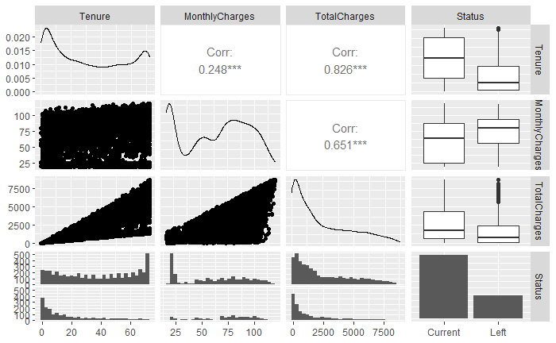

```r
numeric_var_names <- data %>% select_if(is.numeric) %>% colnames()
numeric_var_names[5] <- "Status"


#Viewing relationships between numeric variables and status
data %>%
  select(all_of(numeric_var_names)) %>%
  select(-data$SeniorCitizen) %>%
    GGally::ggpairs(progress = FALSE)
```

#### Qualitative Data Values (Post-Cleaning)

```r
#Lets check the unique values in each character column
data %>% select_if(is.character) %>%
  sapply(function(x) unique(x))
```

```
$Gender
[1] "Female" "Male"

$Partner
[1] "Yes" "No"

$Dependents
[1] "No"  "Yes"

$PhoneService
[1] "No"  "Yes"

$MultipleLines
[1] "No"  "Yes"

$InternetService
[1] "DSL"         "Fiber optic" "No"

$OnlineSecurity
[1] "No"  "Yes"

$OnlineBackup
[1] "Yes" "No"

$DeviceProtection
[1] "No"  "Yes"

$TechSupport
[1] "No"  "Yes"

$StreamingTV
[1] "No"  "Yes"

$StreamingMovies
[1] "No"  "Yes"

$Contract
[1] "Month-to-month" "One year"       "Two year"

$PaperlessBilling
[1] "Yes" "No"

$PaymentMethod
[1] "Electronic check"          "Mailed check"              "Bank transfer (automatic)"
[4] "Credit card (automatic)"
```

```r
#Split qualitative variable names into service and demographic lists for later use against status and each other.
Demographic_vars <- c("Gender","Partner","Dependents","SeniorCitizen")
Service_Vars <- colnames(data %>% select_if(is.character) %>% select(-any_of(Demographic_vars)))
```

## Modeling Code

### Logistic Regression

```r
# create train/test split data for models
set.seed(123)  # for reproducibility

split  <- initial_split(data, prop = 0.7)
data_train  <- training(split)
data_test   <- testing(split)
kfold <- vfold_cv(data_train, v = 5)


# train model via cross validation
lr_mod <- logistic_reg()
results <- fit_resamples(lr_mod, Status ~ ., kfold)

# Check out the cross-validated ROC-AUCs and their average using the training data
collect_metrics(results, summarize = FALSE) %>% filter(.metric == "roc_auc")
```

| id | .metric | .estimator | .estimate | .config |
| --- | --- | --- | --- | --- |
| Fold1 | roc_auc | binary | 0.8561087 | Preprocessor1_Model1 |
| Fold2 | roc_auc | binary | 0.8409836 | Preprocessor1_Model1 |
| Fold3 | roc_auc | binary | 0.8412698 | Preprocessor1_Model1 |
| Fold4 | roc_auc | binary | 0.8241681 | Preprocessor1_Model1 |
| Fold5 | roc_auc | binary | 0.8583890 | Preprocessor1_Model1 |

```r
collect_metrics(results) %>% filter(.metric == "roc_auc")
```

| .metric | .estimator | mean | n | std_err | .config |
| --- | --- | --- | --- | --- | --- |
| roc_auc | binary | 0.8441839 | 5 | 0.006177986 | Preprocessor1_Model1 |

```r
NA
```

```r
# retrain the model across the entire training data
final_fit_lr <- logistic_reg() %>%
  fit(Status ~ ., data = data_train)

# Creating tests against test data.
final_fit_lr %>%
  predict(data_train) %>%
  bind_cols(data_train %>% select(Status)) %>%
  conf_mat(truth = Status, estimate = .pred_class)
```

```
          Truth
Prediction Current Left
   Current    3191  589
   Left        373  746
```

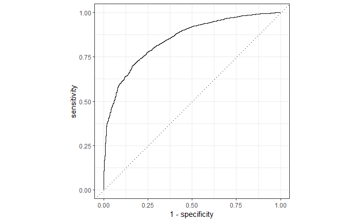

```r
log_regression_auc_plot <-final_fit_lr %>%
  predict(data_train, type = "prob") %>%
  mutate(truth = data_train$Status) %>%
  roc_curve(truth, .pred_Current) %>%
  autoplot()

log_regression_auc_plot
```

```r
log_regression_conf_matrix <- final_fit_lr %>%
  predict(data_train) %>%
  mutate(truth = data_train$Status) %>%
  conf_mat(truth, .pred_class)

log_regression_conf_matrix
```

```
          Truth
Prediction Current Left
   Current    3191  589
   Left        373  746
```

```r
log_regression_auc <- final_fit_lr %>%
  predict(data_train, type = "prob") %>%
  mutate(truth = data_train$Status) %>%
  roc_auc(truth, .pred_Current)

log_regression_auc
```

| .metric | .estimator | .estimate |
| --- | --- | --- |
| roc_auc | binary | 0.8481215 |

```r
NA
```

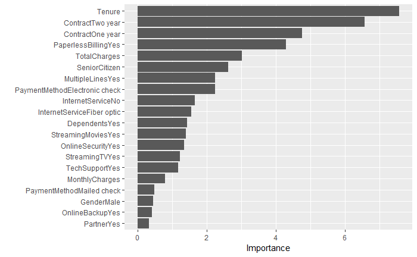

```r
log_regression_vip <- vip(final_fit_lr$fit, num_features = 20)

log_regression_vip
```

### Regularized Logistic Regression

This is similar to above, but with regularization variables that need to be tuned with a recipe and normalized. This is better than basic logistic regression because it: - No longer assumes a linear relationship - Keeps multicolinnearity in mind, which has already been identified in the data

```r
set.seed(123)
# Step 1: create ridge model object
reg_mod <- logistic_reg(penalty = tune(), mixture = tune()) %>%
   set_engine("glmnet") %>%
   set_mode("classification")

# Step 2: Create a tuning grid
reg_grid <- grid_regular(mixture(), penalty(), levels = 5)

# Step 3: create model & preprocessing recipe
model_recipe <- recipe(Status ~ ., data = data_train) %>%
  step_normalize(all_numeric_predictors()) %>%
  step_YeoJohnson(all_numeric_predictors()) %>%
  step_dummy(all_nominal_predictors())

# Step: Resampling of data
kfold2 <- vfold_cv(data_train, v = 5, strata = "Status")

# Step 4: create a tuned workflow object to combine the recipe & model
tuning_results1 <- workflow() %>%
   add_recipe(model_recipe) %>%
   add_model(reg_mod) %>%
   tune_grid(resamples = kfold2, grid = reg_grid)

tuning_results1 %>%
   show_best(metric = "roc_auc")
```

| penalty | mixture | .metric | .estimator | mean | n | std_err | .config |
| --- | --- | --- | --- | --- | --- | --- | --- |
| 1.000000e-10 | 0.0 | roc_auc | binary | 0.8434095 | 5 | 0.01079859 | Preprocessor1_Model01 |
| 3.162278e-08 | 0.0 | roc_auc | binary | 0.8434095 | 5 | 0.01079859 | Preprocessor1_Model02 |
| 1.000000e-05 | 0.0 | roc_auc | binary | 0.8434095 | 5 | 0.01079859 | Preprocessor1_Model03 |
| 3.162278e-03 | 0.0 | roc_auc | binary | 0.8434095 | 5 | 0.01079859 | Preprocessor1_Model04 |
| 3.162278e-03 | 0.5 | roc_auc | binary | 0.8433841 | 5 | 0.01076332 | Preprocessor1_Model14 |

```r
NA
```

```r
# Based on the results, re-tune with new parameters

# Create a tuning grid
reg_grid2 <- grid_regular(mixture(range = c(0,0.5)), penalty(range = c(0,0.003)), levels = 5)

# Create model & preprocessing recipe
model_recipe2 <- recipe(Status ~ ., data = data_train) %>%
  step_normalize(all_numeric_predictors()) %>%
  step_YeoJohnson(all_numeric_predictors()) %>%
  step_dummy(all_nominal_predictors())

# Step 4: create a tuned workflow object to combine the recipe & model
tuning_results2 <- workflow() %>%
   add_recipe(model_recipe2) %>%
   add_model(reg_mod) %>%
  tune_grid(resamples = kfold2, grid = reg_grid2)

tuning_results2 %>%
   show_best(metric = "roc_auc")
```

| penalty | mixture | .metric | .estimator | mean | n | std_err | .config |
| --- | --- | --- | --- | --- | --- | --- | --- |
| 1.000000 | 0 | roc_auc | binary | 0.8373328 | 5 | 0.01005112 | Preprocessor1_Model01 |
| 1.003460 | 0 | roc_auc | binary | 0.8373296 | 5 | 0.01005442 | Preprocessor1_Model03 |
| 1.001728 | 0 | roc_auc | binary | 0.8373296 | 5 | 0.01005278 | Preprocessor1_Model02 |
| 1.005194 | 0 | roc_auc | binary | 0.8373233 | 5 | 0.01005475 | Preprocessor1_Model04 |
| 1.006932 | 0 | roc_auc | binary | 0.8373181 | 5 | 0.01005410 | Preprocessor1_Model05 |

```r
tuning_results2 %>%
  select_best(metric = "roc_auc")
```

| penalty | mixture | .config |
| --- | --- | --- |
| 1 | 0 | Preprocessor1_Model01 |

```r
best_hyperparameters_reg <- select_best(tuning_results2, metric = "roc_auc")
```

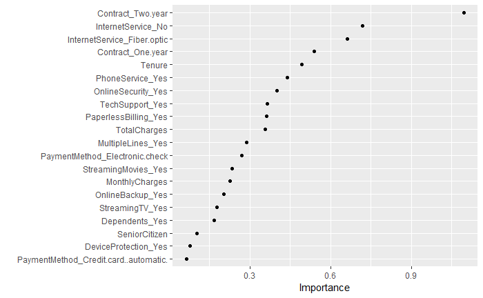

```r
# Step 5: Create a finalized workflow
final_wf_reg <- workflow() %>%
   add_recipe(model_recipe2) %>%
   add_model(reg_mod) %>%
   finalize_workflow(best_hyperparameters_reg)

# Step 6: Fit final model on all training data
final_fit_reg <- final_wf_reg %>%
   fit(data = data_train)

# Step 7: Assess top 20 most influential features
reg_regression_vip <- final_fit_reg %>%
   extract_fit_parsnip() %>%
   vip(num_features = 20, geom = "point")

reg_regression_vip
```

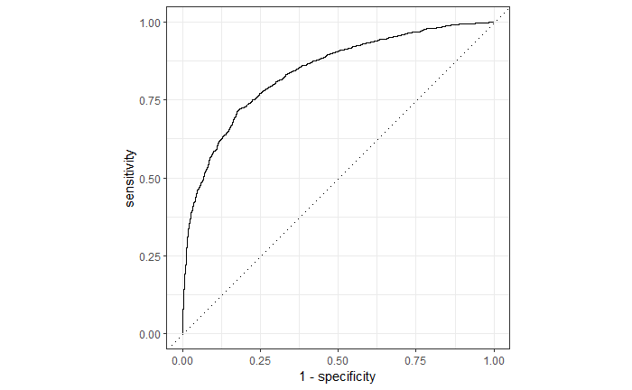

```r
# Step 8: Test the final, fitted workflow against test data and output the result.
reg_regression_auc_plot <- final_fit_reg %>%
  predict(data_train, type = "prob") %>%
  mutate(truth = data_train$Status) %>%
  roc_curve(truth, .pred_Current) %>%
  autoplot()

reg_regression_auc_plot
```

```r
reg_regression_conf_matrix <- final_fit_reg %>%
  predict(data_train) %>%
  bind_cols(data_train %>% select(Status)) %>%
  conf_mat(truth = Status, estimate = .pred_class)

reg_regression_conf_matrix
```

```
          Truth
Prediction Current Left
   Current    3564 1335
   Left          0    0
```

```r
reg_regression_auc <- final_fit_reg %>%
  predict(data_train, type = "prob") %>%
  mutate(truth = data_train$Status) %>%
  roc_auc(truth, .pred_Current)

reg_regression_auc
```

| .metric | .estimator | .estimate |
| --- | --- | --- |
| roc_auc | binary | 0.8395802 |

### Decision Trees

```r
# Create a modified decision tree
dt_mod <- decision_tree(
  mode = "classification",
  cost_complexity = tune(),
  tree_depth = tune(),
  min_n = tune()
  ) %>%
  set_engine("rpart")

# Create model recipe
dt_recipe <- recipe(Status ~ ., data = data_train)

# create the hyperparameter grid
dt_hyper_grid <- grid_regular(
  cost_complexity(),
  tree_depth(),
  min_n(),
  levels = 5
  )

# train model across the hyper parameter grid
dt_results <- tune_grid(dt_mod, dt_recipe, resamples = kfold, grid = dt_hyper_grid)

# get best results
show_best(dt_results, metric = "roc_auc", n = 5)
```

| cost_complexity | tree_depth | min_n | .metric | .estimator | mean | n | std_err | .config |
| --- | --- | --- | --- | --- | --- | --- | --- | --- |
| 1.000000e-10 | 8 | 30 | roc_auc | binary | 0.8186920 | 5 | 0.004665701 | Preprocessor1_Model086 |
| 1.778279e-08 | 8 | 30 | roc_auc | binary | 0.8186920 | 5 | 0.004665701 | Preprocessor1_Model087 |
| 3.162278e-06 | 8 | 30 | roc_auc | binary | 0.8186920 | 5 | 0.004665701 | Preprocessor1_Model088 |
| 1.000000e-10 | 4 | 2 | roc_auc | binary | 0.8153728 | 5 | 0.009568594 | Preprocessor1_Model006 |
| 1.778279e-08 | 4 | 2 | roc_auc | binary | 0.8153728 | 5 | 0.009568594 | Preprocessor1_Model007 |

```r
best_dt_params <- select_best(dt_results, metric = "roc_auc")
best_dt_params
```

| cost_complexity | tree_depth | min_n | .config |
| --- | --- | --- | --- |
| 1e-10 | 8 | 30 | Preprocessor1_Model086 |

```r
# put together final workflow
dt_final_wf <- workflow() %>%
  add_recipe(dt_recipe) %>%
  add_model(dt_mod) %>%
  finalize_workflow(best_dt_params)

# fit final workflow across entire training data
dt_final_fit <- dt_final_wf %>%
  fit(data = data_train)

# Test decision tree across test data and output
decision_tree_auc <- dt_final_fit %>%
  predict(data_train, type = "prob") %>%
  mutate(truth = data_train$Status) %>%
  roc_auc(truth, .pred_Current)

decision_tree_auc
```

| .metric | .estimator | .estimate |
| --- | --- | --- |
| roc_auc | binary | 0.8576021 |

```r
decision_tree_conf_matrix <- dt_final_fit %>%
  predict(data_train) %>%
  mutate(truth = data_train$Status) %>%
  conf_mat(truth = truth, estimate = .pred_class)

decision_tree_conf_matrix
```

```
          Truth
Prediction Current Left
   Current    3182  502
   Left        382  833
```

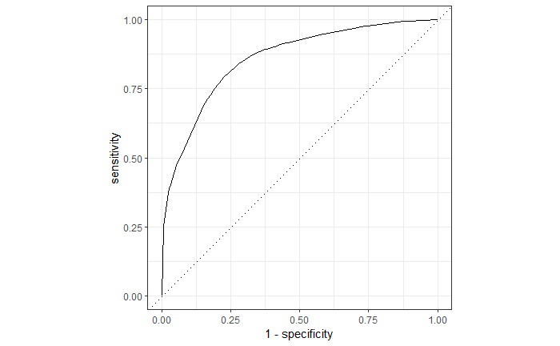

```r
decision_tree_auc_plot <- dt_final_fit %>%
  predict(data_train, type = "prob") %>%
  mutate(truth = data_train$Status) %>%
  roc_curve(truth, .pred_Current) %>%
  autoplot()

decision_tree_auc_plot
```

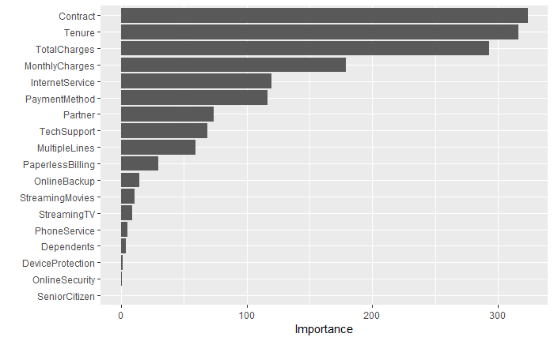

```r
# plot feature importance
decision_tree_vip <- dt_final_fit %>%
  extract_fit_parsnip() %>%
  vip(20)

decision_tree_vip
```

## Modeling Output Analysis

1. Basic Logistic Regression
2. Regularized and Tuned Logistic Regression
3. Tuned Decision Tree Model

#### Confusion Matrices:

Taking a look at the confusion matrices, we can see that the regularized regression model chose to predict EACH customer to stay, with nobody leaving. After re-testing multiple times, this really is the outcome of the model. Based on this information, we can conclude that the Regularized Regression model will not serve our interests at Regork.

```r
log_regression_conf_matrix
```

```
          Truth
Prediction Current Left
   Current    3191  589
   Left        373  746
```

```r
reg_regression_conf_matrix
```

```
          Truth
Prediction Current Left
   Current    3564 1335
   Left          0    0
```

```r
decision_tree_conf_matrix
```

```
          Truth
Prediction Current Left
   Current    3182  502
   Left        382  833
```

#### Area Under the Curve:

```r
log_regression_auc
```

| .metric | .estimator | .estimate |
| --- | --- | --- |
| roc_auc | binary | 0.8481215 |

```r
reg_regression_auc
```

| .metric | .estimator | .estimate |
| --- | --- | --- |
| roc_auc | binary | 0.8395802 |

```r
decision_tree_auc
```

| .metric | .estimator | .estimate |
| --- | --- | --- |
| roc_auc | binary | 0.8576021 |

#### AUC Curves

Finally, a quick visualization of the curves complementing each AUC metric.

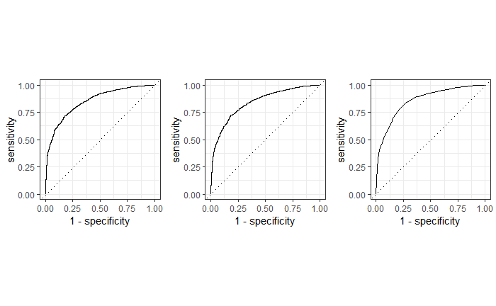

```r
grid.arrange(log_regression_auc_plot, reg_regression_auc_plot, decision_tree_auc_plot, ncol = 3)
```

#### Best Model and Important Variables

Since we are using the decision tree model, let’s look at the important variables identified through that model and compare it to the basic Logistic Regression VIP:

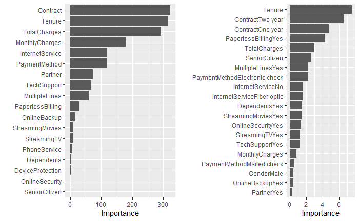

```r
grid.arrange(decision_tree_vip, log_regression_vip, ncol = 2)
```

Our two best models both note that Tenure and Contract are extremely important features to predict customer churn. Additionally, the logistic regression model notes that a two-year contract has a larger effect on customer retention than a one-year contract. From this, we learn that longer tenure and two-year contracts increase incentives to stay with Regork.

Now honing into the decision tree VIP only:

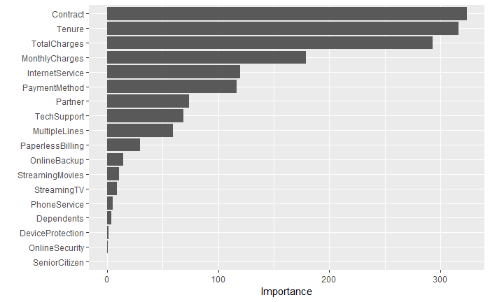

```r
decision_tree_vip
```

After contract and tenure, money serves as the main factor affecting customer retention. This makes sense, as telecommunications serves as a basic commodity in the market, making price an extremely important factor in choosing a service company.

But how does this model perform against unseen data? Take a look at the comparison between training AUC and testing AUC below (in order).

```r
dt_final_fit %>%
  predict(data_train, type = "prob") %>%
  mutate(truth = data_train$Status) %>%
  roc_auc(truth, .pred_Current)
```

| .metric | .estimator | .estimate |
| --- | --- | --- |
| roc_auc | binary | 0.8576021 |

```r
dt_final_fit %>%
  predict(data_test, type = "prob") %>%
  mutate(truth = data_test$Status) %>%
  roc_auc(truth, .pred_Current)
```

| .metric | .estimator | .estimate |
| --- | --- | --- |
| roc_auc | binary | 0.8331794 |

**Survey says**: A slightly lower accuracy, but still acceptable for Regork’s purposes.

## Business Analysis and Conclusion

#### Important Business Factors:

Based on the decision tree’s analysis, the top three factors to focus on are:

1. *Tenure*: The longer Regork retains a customer, the lower their chance of churn
2. *Contract*: Longer contracts = lower churn
3. *Total Spend*: Price plays an important role in customer retention regarding the commodity of telecommunications.

#### Predicted Churn and Losses

Before creating an action plan to retain customers, let’s figure out the potential losses related customers who are predicted to leave.

```r
test_prediction <- as.data.frame(predict(dt_final_fit, data_test))

churn_customers <- data_test %>%
  mutate(prediction = test_prediction$.pred_class) %>%
  filter(Status == "Current", prediction == "Left")

head(churn_customers %>% select(Status, prediction))
```

|  | Status | prediction |
| --- | --- | --- |
| 1 | Current | Left |
| 2 | Current | Left |
| 3 | Current | Left |
| 4 | Current | Left |
| 5 | Current | Left |
| 6 | Current | Left |

Notice we’re only looking at customers still with the company who are predicted to leave. Below shows the predicted worth of these customers’ monthly revenue.

```r
churn_customers %>%
  summarize(potential_losses = sum(MonthlyCharges),
            avg_loss_per_customer = sum(MonthlyCharges)/n())
```

| potential_losses | avg_loss_per_customer |
| --- | --- |
| 16861.55 | 75.61233 |

```r
NA
```

Oof. It looks like Regork stands to **lose** around **$16,800** per month due to customer churn. That’s an estimated **$201,600 per** year… Just on the test data! Finally, it seems that each customer brings in around $75 per month.

#### Solution

We know that customers bring in an average of $75 per month, and Regork requires a 20% top-line profit to fulfill all expenses (and other programs) and still make a bottom line profit. This leaves us with ~$60 to spend per customer on a new promotional program.

#### Limitations

- Small dataset. Great for training a model, but not great for companywide analysis
- Unkown data source. Retrieved from a third party, with no way to validate data
- No additional data to test model against
- Unable to “reality-check” action plan against current business conditions.
- Models could use additional tuning (especially the regularized logistic regression)

## Conclusion Statement:

After testing Logistic Regression, Regularized Logistic Regression, and Decision Tree Models, the Decision Tree Model provided the best accuracy with an AUC of 0.85 on training data and 0.83 on test data.

Based on the results from the decision tree, Regork stands to lose $16,800 per month, $201,600 per year, and $75 per customer from current customers predicted to churn. Additionally, the model noted that Tenure, Contract Type, and Total Cost serve as the three most important features in determining customer retention.

In order to reduce customer churn and later losses, the following action plan is recommended: